# The Formula 1 2022 Regulations Preliminary Report

## What is this report about?

Formula 1 has a long, storied history. Considered the Pinnacle of motorsport, there is nothing like it in the world. Single seater, open wheeled cars engineered to perfection, taking corners at impossible speeds, and propelling auto technology to heights never thought possible. Unfortunately, like any other sport, Formula 1 is not perfect, and just like any other sport, it has seen periods of domination where one team would win it all without mercy and not let any other team enjoy a moment in the spotlight. To combat that, the governing body called the FIA changes regulations of Formula 1 cars every few years to shake up the grid and hopefully make competition much closer. Most recently, Mercedes has completely obliterated the competition in the turbo-hybrid era that started in 2014. With the exception of the 2021 season, no team has even come close in performance to Mercedes. The solution was the 2022 regulations, which brought about the biggest change to how the cars are built in the history of the sport. Unfortunately after seeing the 2022 and beginning of the 2023 seasons, some people claim that the new regulations have not improved competition, as the sport has entered an era of domination not by Mercedes, but by Red Bull Racing. This report aims to find the answer to this divide, centered around one question:

## Have the 2022 regulations helped bring competition closer, and do Formula 1 fans enjoy the sport more than in the past?

To answer this question, I want to approach the answer from 2 different points of view. The objective point of view looking at the data collected on cars through races and seasons. The second point of view is more subjective, looking at whether the fans enjoy the racing now more than they did in the past by looking at attendance records at different events throughout the years. This leads us to the first source which is the telemetry records shown to fans on the F1 website and app:

- Where did you find them? This telemetry information was provided officially by Formula 1 to the fans. While there is no link to directly access the data. It is available to members of F1TV (F1’s streaming service) as part of the race broadcast.
- Who collected/maintains them? The data is collected and maintained by Formula 1. Unfortunately there is no public API to easily access these records for personal use, so members in the community have created a third party python library that parses the information for you called FastF1. Their documentation site, which includes a link to their source code can be found here: https://theoehrly.github.io/Fast-F1/
- When & Why were they originally collected? The data is recorded live at each event as it happens, with records tracing back to 2018. The purpose of collecting this telemtry is for viewers to be able to “supplement” their viewing experience of the TV broadcast with live car data if they so wish.
- What does a case represent in each data source, and how many total cases are available? That depends on the Data you are collecting, it can vary from each case representing a car’s laptime, to a case representing a single car’s speed/coordinates at a certain point of time on track. There is a lot of data so working through it without getting a subset of relevant information is all but impossible. Since a single lap can have hundreds of data points, for a single car out of 20, where each does up to 80 laps in a race, with 20 races a year and 5 years of data. We have hundreds of thousands if not millions of pieces of data. In my case, I will be mostly looking at lap times and speed statistics. For example below is a graph of the driver Charles Leclerc in his fastest qualifying lap of the 2019 Italian grand prix. Shown is his cars speed over the course of the lap.

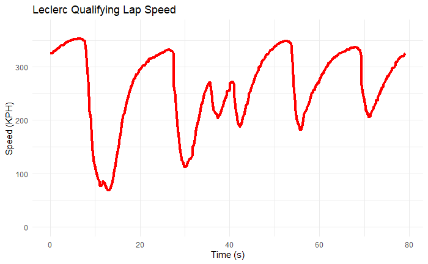

- What are some of the variables that you plan to use? Some variables I plan to use are the lap times and car speeds as quantitative variables, with the cars being separated into teams and engine manufacturers as categorical variables. The graph above was an example of what a graph of car speed over time looks like. Attached below is the data table used for this graph. Margins in Formula 1 are so small that time is measured in milliseconds as anything more broad will not be accurate enough, so to keep integrity of data I will not round times beyond the nearest millisecond.

| timeData | speedData |
| --- | --- |
| 0.048 | 326 |
| 0.288 | 325 |
| 0.527 | 327 |
| 0.728 | 329 |
| 0.968 | 330 |
| 1.208 | 331 |
| 1.448 | 333 |
| 1.688 | 335 |
| 1.928 | 336 |
| 2.168 | 338 |

[output cut: 321 more lines]

- The R Notebook should include R code chunks & output as well as narrative (bullet list is fine at this stage) as you answer these questions

For my second source I am choosing to look at how fans see the change in regulations, in this case I have chosen to look at track attendance data as my secondary source.

- Where did you find them? For a secondary source I have 2 tables of track attendance. One from 2021, the last year of the old regulations, and 2022, the first year of the new regulations. Both data tables were obtained from the Statista website as part of some of the data freely provided to education accounts. 2022: https://www.statista.com/statistics/271306/formula-1-revenue-in-2009-by-sector/ and 2021: https://www.statista.com/statistics/1295848/formula-1-attendance/
- Who collected/maintains them? Statista collects and maintains the data
- When & Why were they originally collected? The 2021 and 2022 tables were collected at the end of 2021 and 2022 respectively and released in Feb 2022 and March 2023 respectively.
- What does a case represent in each data source, and how many total cases are available? In both tables, a case represents an event and the weekend attendance for said event. For example, here is a bar chart of race attendance in 2022.

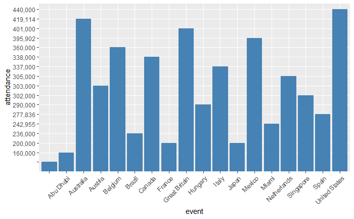

- What are some of the variables that you plan to use? I am planning on using the difference in attendance in events between the 2 years to measure the change in interest from fans between the 2 years.

As some informative plots I decided to start simple and compare the speeds of the 2 top drivers in 2021. Max Verstappen and Lewis Hamilton fought for the championship throughout the entire season and are very comparable in terms of skill levels. I created 2 plots, comparing their speeds throughout a lap around the Monza track in 2021 and 2022.

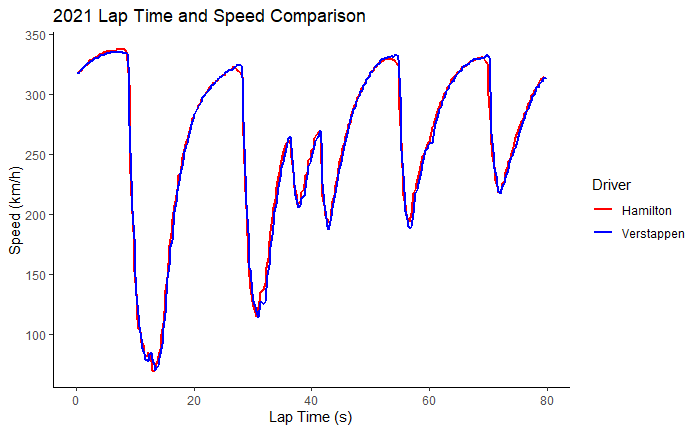

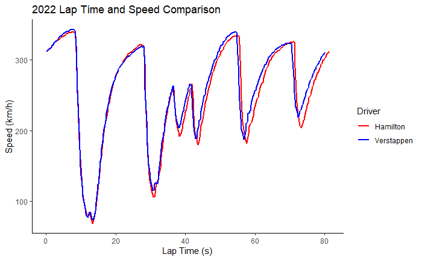

Just from these 2 graphs we can see that there might be some merit to people’s claims that the 2022 regulations have not helped reduce competition but actually created a gap that was not there before. In the 2021 graph you can see that Hamilton and Verstappen are almost identical in terms of pace. In a sport where margins are measured in milliseconds this is an incredible achievement from both drivers and teams. However in 2022, you can see a much bigger difference between the drivers. Max Verstappen’s Red Bull has much higher “low points” (which indicate a corner) showing that the new regulations helped red bull find a car with much better cornering speeds than Lewis Hamilton’s Mercedes. Verstappen’s lap domain is also smaller, meaning he finished his lap with a faster time than Hamilton. If we were to compare Verstappen’s and Hamilton’s average speeds in 2021 of 259.3892216 and 260.6163142 respectively we can see they were almost identical and a difference this small could be attributed to track conditions not being identical in each driver’s runs. Now if we compare the 2022 average speeds of 257.4483871 and 252.8726115 respectively, we can see Max Verstappen had an almost 5 KMH speed advantage compared to hamilton over a lap. This is a very significant difference in speeds between the two cars that cannot be explained with just differing track conditions.

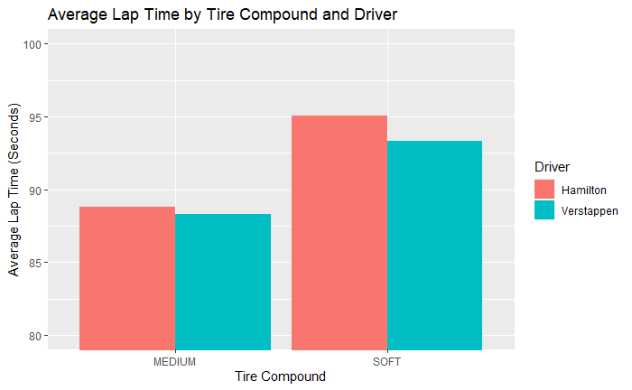

In terms of fan support. The plot below shows the net change in attendance in races that were held both in 2021 and 2022.

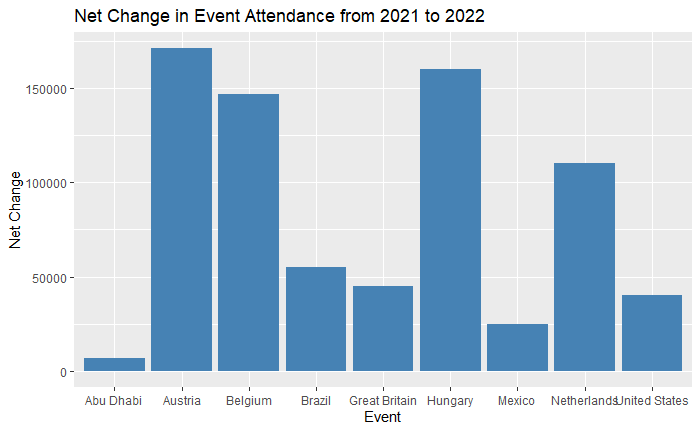

Looking at this graph alone, Something certainly can be said as to the increase in popularity of races from 2021 to 2022. In all the overlapping races for which data was available, there was a net increase in attendance, with some countries, especially in Europe, seeing massive increase in attendance. All of the events listed occured during lulls in the COVID 19 pandemic when little to no travel restrictions were present so as a preliminary conclusion, we can say that with the effect of COVID 19 on attendance being negligble (countries that did have restrictions in 2021 have had their events cancelled and are not on this list, such as Australia and Japan. Though it should be mentioned that both races occured in 2022. The 2023 Australian grand prix occurred on April 2nd and had the highest attendance of the sport’s history in Australia. The 2023 Japanese grand prix has yet to happen and is scheduled for october 2023), the sport’s popularity certainly grew even if some people claim that competitiveness has taken a hit with the new regulations.